# **Proyecto semestral: Hito 3**

Nicolás Herrera, Yesenia Marulanda, Franco Migliorelli, Samuel Sánchez, Sebastián Urbina

Enero 2021

## Motivacion

En el siguiente documento se pretende buscar el mejor clasificador de sentimientos para los tweets analizados. Para esto se requerira realizar una mejor etapa de preprocesamiento y limpieza de datos, ademas de utilizar diferentes metodologías que permiten realizar la vectorizacion de los comentarios, como se detallará más adelante.

```python
#Se importan las librerías
import numpy as np
import pandas as pd
import seaborn as sns
from matplotlib import pyplot as plt
from nltk import word_tokenize
from nltk.stem import SnowballStemmer
from matplotlib import rcParams
import nltk
from wordcloud import  STOPWORDS
rcParams["figure.figsize"] = 12,8
nltk.download('all', quiet = True)
# Graphics in SVG format are more sharp and legible
%config InlineBackend.figure_format = 'svg'
pd.set_option("display.precision", 2)

#word2vec
from gensim.models import Word2Vec
from gensim.models.phrases import Phrases, Phraser
```

```python
#Se importa el drive para poder trabajar con las tablas .csv guardadas ahí
from google.colab import drive
drive.mount('/content/drive')
```

Cargamos los mismos datos usados anteriormente en la etapa de exploracion, correspondiente a un dataset extraido de la plataforma *kaggle*[1] compuesto por 44.955 tweets publicados desde el 2 de marzo al 14 de abril de 2020.

```python
test = pd.read_csv("/content/gdrive/MyDrive/Colab Notebooks/Data/Corona_NLP_test.csv", encoding="utf-8")
train = pd.read_csv("/content/gdrive/MyDrive/Colab Notebooks/Data/Corona_NLP_train.csv", encoding="latin-1")
data = pd.concat([test,train])
```

y revisamos su distribucion por sentimiento.

```python
data.groupby(pd.Grouper(key = "Sentiment")).size().reset_index()
```

|  | Sentiment | 0 |
| --- | --- | --- |
| 0 | Extremely Negative | 6073 |
| 1 | Positive | 12369 |
| 2 | Extremely Positive | 7223 |
| 3 | Negative | 10958 |
| 4 | Neutral | 8332 |

Podemos apreciar que cerca de un 43.6% de los datos corresponden a comentarios calificados como positivos o extremadamente positivos, 37.9% como negativos o extremadamente negativos y 18.5% como neutrales.

## Preprocesamiento

De igual forma que antes, para poder analizar los contenidos de los tweets es necesario realizar una limpieza y normalizacion de estos. Agregamos entonces una columna con los Tweets tokenizados, es decir, en listas con las palabras que aportan información. Para esto utilizamos `stopwords` de `nltk` para limpiar los tweets

```python
stopwords = set(STOPWORDS)
#se agregan estas palabras a las palabras que son consideradas inutiles
stopwords.update(["dtype","#","com","cl","es",",","@",":",";",".","*","https","http","www","coronavirus","covid19","covid"])
#input: tweet, en este caso es una frase
#return: la frase sin palabras que no aportan información
def tokenize_tweets(tweet):
    """
    Listar tweets limpios
    """
    tweet_clean = []
    tokenize_tweet = word_tokenize(tweet, language = "english")
    for c in tokenize_tweet:
        c = c.lower()
        if c not in stopwords and c.isalpha():
            tweet_clean.append(c)
    return tweet_clean

data["Tokenize_Tweet"] = data["OriginalTweet"].apply(lambda x : tokenize_tweets(x)) #Creamos una columna con los tweets "tokenizados" o en una "lista con palabras"
data["Tokenize_Tweet"]
```

```
0        [trending, new, yorkers, encounter, empty, sup...
1        [find, hand, sanitizer, fred, meyer, turned, a...
2                             [find, protect, loved, ones]
3        [panic, buying, hits, newyork, city, anxious, ...
4        [toiletpaper, dunnypaper, coronavirusaustralia...
                               ...
41152    [airline, pilots, offering, stock, supermarket...
41153    [response, complaint, provided, citing, relate...
41154    [know, getting, tough, kameronwilds, rationing...
41155      [wrong, smell, hand, sanitizer, starting, turn]
41156    [tartiicat, well, rift, s, going, amazon, rn, ...
Name: Tokenize_Tweet, Length: 44955, dtype: object
```

Creamos una función que lo que hace es convertir la columna de tweets tokenizados a una lista que contiene en cada posición el tweet completo limpio, es decir, sin las `stopwords`

```python
from sklearn.feature_extraction.text import CountVectorizer

all_list = data["Tokenize_Tweet"].values

def tweet_to_list(df):
    """
    Función que crea una lista que contiene un string de cada tweet
    """
    tweets = []
    all_list = df.values
    for tweet_tokenize in all_list:
        tweets.append(" ".join(tweet_tokenize))
    return tweets

tweet_list = tweet_to_list(data["Tokenize_Tweet"])
assert len(tweet_list) == data.shape[0] #Aseguramos que se haya construido bien la lista con tweets
print(len(tweet_list))
print(tweet_list[1])
```

```
44955
find hand sanitizer fred meyer turned amazon pack purell check concerns driving prices
```

Definimos las clases que serán útiles mas adelante para entrenar el modelo, considerando sólo tweets positivos, negativos y neutros, agrupandos aqulleos considerados "extremadamente" en sus respectivas categorias.

```python
#input: clasificación manual
#output: número que representa la clasificación manual
def def_clases(sentiment):
    """
    Función que caracteriza sólo sentimientos positivos y negativos
    """
    neg = ["Extremely Negative", "Negative"]
    pos = ["Extremely Positive", "Positive"]
    if sentiment in neg:
        return 1
    elif sentiment in pos:
        return 2
    else:
        return 0

data["Clase"] = data["Sentiment"].apply(lambda x: def_clases(x)) #Aplicamos el cambio
```

### Extracción de frases

Utilizando las herramientas de gensim: Phraser y phrases, identificamos aquellos bigramas más comunes para luego aplicarlos a los tweets y obtener más información

```python
phrases = Phrases(data["Tokenize_Tweet"].values, min_count = 10, progress_per = 5000) #selecciona los bigramas que aparecen más de 10 veces
#phrases.vocab
bigram = Phraser(phrases) #
tweets = bigram[data["Tokenize_Tweet"].values] #limpia los tweets considerando los bigramas
```

Se puede notar en el siguiente caso que se detectó "driving" y "prices" como un bigrama

```python
print(data.Tokenize_Tweet.values[1])
print(tweets[1])
```

```
['find', 'hand', 'sanitizer', 'fred', 'meyer', 'turned', 'amazon', 'pack', 'purell', 'check', 'concerns', 'driving', 'prices']
['find', 'hand_sanitizer', 'fred', 'meyer', 'turned', 'amazon', 'pack', 'purell', 'check', 'concerns', 'driving_prices']
```

### Word2Vec para crear embeddings[2]

Utilizaremos un modelo Skip-Gram, el cual nos permite entrenar una red neuronal de una hidden layer para predecir el contexto de los tweets, es decir, intenta predecir las palabras presentes en una ventana de tamaño `window`, lo que se entrega como parámetro

Creamos el modelo y definimos los siguientes parámetros:

- min_count: se ignoran todas aquellas palabras que aparecen menos de 10 veces
- window: se consideran las 2 palabras de izquierda y derecha de la palabra cetral
- size: Es el tamaño de los embeddings, es decir, la cantidad de neuronas que tiene la capa oculta

```python
tweets_w2v = Word2Vec(min_count = 10,
                      window = 2,
                      size = 200)
```

Entrenamos el modelo...

```python
from time import time
#Para esto, se creará un conjunto que contendrá (una sola vez) todas aquellas palabras que aparecen mas de min_count veces.
tweets_w2v.build_vocab(tweets, progress_per=10000)

t = time()
tweets_w2v.train(tweets, total_examples = tweets_w2v.corpus_count, epochs = 15, report_delay = 10)
print("Time to train the model: {} mins".format(round((time()-t)/60,2)))
```

```
Time to train the model: 0.86 mins
```

```python
#Indicamos que no entrenaremos más el modelo
tweets_w2v.init_sims(replace = True)
```

```python
vocabulary = tweets_w2v.wv.vocab
#print(vocabulary)
print("Palabras:",len(vocabulary))
```

```
Palabras: 8132
```

También podemos ver los pesos del modelo para alguna palabra particular del modelo ya entrenado

```python
print(tweets_w2v["trending"])
```

```
[-0.04893864 -0.07702914  0.13478887 -0.05502075  0.01573594  0.11363654
  0.16161773  0.00848006 -0.00810148 -0.01274007 -0.09204856 -0.04456872
  0.00796548  0.08769223 -0.1323552   0.0008319   0.05960764 -0.08284156
 -0.03479729  0.05257658 -0.10481595  0.04630188  0.01384913  0.04498442
 -0.08907476 -0.00426615 -0.02878058  0.12369671  0.05465516  0.06492192
  0.1328329  -0.04031633 -0.04072366 -0.03373453 -0.04590518  0.05431545
  0.08007086  0.06136715 -0.01805517  0.06123655  0.0269745  -0.0711645
 -0.03716662 -0.02840639 -0.07847895  0.00373562 -0.03657898  0.10977532
  0.13776857  0.13958974 -0.03174105  0.04897631 -0.03006127  0.05233978
  0.04615439 -0.05042828 -0.00595957  0.0345371   0.07191699 -0.11926915
  0.13579856 -0.01918575 -0.01928443 -0.01715023  0.07925544  0.02635221
 -0.01081655 -0.1147294   0.02546271 -0.12761576  0.09587085  0.0383396
  0.04452765  0.1321162  -0.11843517 -0.00991285 -0.03480303  0.02122982
 -0.0470245   0.07388959 -0.00203837  0.02621458 -0.0524101   0.00436098
  0.03261323  0.03602437  0.01309817  0.01042442  0.0287501  -0.00435261
 -0.00292506  0.0358743  -0.04145225 -0.05518405  0.01835443 -0.00620485
  0.0111633  -0.16131018  0.00307908  0.0788295   0.04265246 -0.07920283
 -0.05773667  0.10069611  0.19212064 -0.01362492  0.01867777  0.03708595
 -0.05857063 -0.01912583 -0.05595361  0.01325713  0.02157968 -0.03392493
  0.01215221 -0.04122834 -0.04283427  0.02760477  0.02484508  0.04932262
 -0.01402696 -0.02439222 -0.06344784  0.06159731 -0.05145198  0.01423596
  0.05596123  0.06726196  0.09449987  0.06632801  0.08117602  0.04995778
  0.00786814  0.05015825 -0.09028192 -0.02378825 -0.06428216 -0.04683686
  0.1495112  -0.03455476 -0.10419017 -0.0162085   0.11523069 -0.08225824
  0.05178548  0.06300585  0.01235029  0.04239541  0.03590567 -0.17477018
  0.00380289  0.11011244  0.00780753 -0.00871965 -0.03481076  0.01008715
  0.05955665 -0.01782961  0.02969315  0.02305262 -0.01624818  0.0165066
 -0.0502459   0.00918514  0.00748419  0.08086633  0.00821241  0.0898387
 -0.06053446 -0.02671746  0.01649479 -0.14966016  0.00453152 -0.06945104
  0.04311745  0.04067597  0.02908846  0.03835476 -0.02076603  0.01711155
  0.0540194  -0.06032525  0.003493    0.28369218  0.12293575 -0.09269139
 -0.05216699 -0.15356202 -0.05444872 -0.01059046 -0.023244   -0.03322519
 -0.03719931 -0.09798193  0.03296608  0.0957413   0.01497845 -0.07462861
  0.02957924 -0.25032735]
```

Corresponde a un vector de 1x200, correspondiente al peso de cada una de las 200 neuronas definidas en la capa oculta

Ahora, utilizando las embeddings procederemos a crear una matriz de entrentamiento. Se creará una matriz de dimensiones (n_tweets,n_neuronas) para testear algunos modelos de clasificación. Se utilizarán diferentes criterios, puesto que cada tweet contiene un conjunto de palabras, se trabajará con el promedio y máximo embedding de las palabras correspondientes a un tweet

## Entrenamiento del modelo.

### Entrenamiento utilizando Word2Vec

```python
def word_vector_mean(tokens, modelo):
    aux = np.zeros((1,200))
    c = 0
    for word in tokens:
        try:
            aux += modelo[word].reshape((1,200))
        except:
            continue
    if c != 0:
        aux /= c
    return aux
```

```python
def word_vector_max(tokens, modelo):
    aux = np.zeros((1,200))
    for word in tokens:
        try:
            vec = modelo[word].reshape((1,200))
            if np.sum(vec)>=np.sum(aux):
                aux = vec
        except:
            continue
    return aux
```

Fuente: https://www.kaggle.com/nitin194/twitter-sentiment-analysis-word2vec-doc2vec

Definimos la función `word_to_vec` que recibe los tweets tokenizados, la función a implementar y el modelo de embeddings.

```python
def word_to_vec(tokens, fun, model):
    """
    Función que convierte los tweets tokenizados a embeddings en base a una función aplicada(fun) que puede ser mean,max,etc. Reduce la dimensionalidad notablemente
    """
    n_tweets = len(tokens)
    X = np.zeros((n_tweets, 200))

    for i in range(n_tweets):
        X[i,:] = fun(tokens[i], model)

    #df_w2v = pd.DataFrame(X)
    return X
```

Ya tenemos todo lo necesario para testear modelos

```python
from sklearn.model_selection import train_test_split
from sklearn.model_selection import train_test_split
from sklearn.tree import DecisionTreeClassifier
from sklearn.metrics import accuracy_score
from sklearn.metrics import classification_report
from sklearn.svm import LinearSVC #svm

#tokens = data["Tokenize_Tweet"].tolist()
X_mean = word_to_vec(tweets, word_vector_mean, tweets_w2v)
X_max = word_to_vec(tweets, word_vector_max, tweets_w2v)
y = data.Clase.to_numpy() #definimos vector de clases
```

Procedemos a entrenar usando SVM. Notamos que MultinomialNB no se puede entrenar con los valores, ya que existen números negativos en los datos. Tampoco se entrenara la base de datos con KNN porque su tiempo de ejecución es demasiado largo.

```python
from sklearn.metrics import classification_report, confusion_matrix
from sklearn.naive_bayes import MultinomialNB  # naive bayes
from sklearn.neighbors import KNeighborsClassifier
from sklearn.svm import LinearSVC, SVC  # support vector machine classifier

#c1 = ("Multinomial Naive Bayes", MultinomialNB())
#c2 = ("KNN", KNeighborsClassifier(n_neighbors=5))
c3 = ("Support Vector Machine", LinearSVC())
classifiers = [c3]

X_train, X_test, y_train, y_test = train_test_split(X_mean, y, test_size=0.33, random_state=42)

for name, clf in classifiers:
    clf.fit(X_train, y_train)
    y_pred = clf.predict(X_test)
    print("----------------")
    print("Resultados para clasificador: ", name)
    g = sns.heatmap(confusion_matrix(y_test, y_pred), annot=True, cmap="Blues", fmt = "d")
    g.set_yticklabels(g.get_yticklabels(), rotation = 0)
    plt.title('Confusion matrix \n')
    plt.xlabel('Predicted label')
    plt.ylabel('True label');
    plt.show()
    print(classification_report(y_test, y_pred))
    print("----------------\n\n")
```

```
----------------
Resultados para clasificador:  Support Vector Machine
```

[figure not shown]

```
              precision    recall  f1-score   support

           0       0.59      0.40      0.48      2730
           1       0.64      0.68      0.66      5627
           2       0.66      0.71      0.69      6479

    accuracy                           0.64     14836
   macro avg       0.63      0.60      0.61     14836
weighted avg       0.64      0.64      0.64     14836

----------------
```

### Ahora estudiaremos resultados pero utilizando un modelo de embeddings previamente entrenado

```python
import gensim.downloader
# Show all available models in gensim-data
print(list(gensim.downloader.info()['models'].keys()))
```

```
['fasttext-wiki-news-subwords-300', 'conceptnet-numberbatch-17-06-300', 'word2vec-ruscorpora-300', 'word2vec-google-news-300', 'glove-wiki-gigaword-50', 'glove-wiki-gigaword-100', 'glove-wiki-gigaword-200', 'glove-wiki-gigaword-300', 'glove-twitter-25', 'glove-twitter-50', 'glove-twitter-100', 'glov…
```

```python
# Download the "glove-twitter-25" embeddings
tw_model = gensim.downloader.load('glove-twitter-200')
```

```
[==================================================] 100.0% 758.5/758.5MB downloaded
```

Un ejemplo de los resultados que se pueden obtener de los embeddings

```python
tw_model.most_similar(positive = "trump")
```

```
[('donald', 0.6552975177764893),
 ('clinton', 0.5108779668807983),
 ('biden', 0.509372353553772),
 ('romney', 0.5069373846054077),
 ('warren', 0.4898340106010437),
 ('birther', 0.4887540638446808),
 ('judd', 0.4777779281139374),
 ('bloomberg', 0.4759959578514099),
 ('ivanka', 0.473548024892807),
 ('reid', 0.4727659225463867)]
```

Código para guardar o cargar modelo de embeddings

```python
#import os
#if not os.path.exists("./pretrained_models"):
#    os.mkdir("./pretrained_models")
#    tweets_w2v.save("./pretrained_models/tweets_w2v.model")

# cargar el modelo (si es que lo entrenaron desde local.)
#biobio_w2v = KeyedVectors.load("./pretrained_models/biobio_w2v.model", mmap='r')
```

Ahora utilizamos los embeddings preentrenados de la librería gensim y los utilizamos para testear los clasificadores

```python
tokens = data["Tokenize_Tweet"].tolist()
X_mean_pretrained = word_to_vec(tokens, word_vector_mean, tw_model)
X_max_pretrained = word_to_vec(tokens, word_vector_max, tw_model)
y = data.Clase.to_numpy() #definimos vector de clases
```

```python
c1 = ("Multinomial Naive Bayes", MultinomialNB())
#c2 = ("KNN", KNeighborsClassifier(n_neighbors=10))
c3 = ("Support Vector Machine", LinearSVC())

classifiers = [c3]

X_train, X_test, y_train, y_test = train_test_split(X_mean_pretrained, y, test_size=0.33, random_state=42)  #utilizamos X_mean

for name, clf in classifiers:
    clf.fit(X_train, y_train)
    y_pred = clf.predict(X_test)
    print("----------------")
    print("Resultados para clasificador: ", name)
    g = sns.heatmap(confusion_matrix(y_test, y_pred), annot=True, cmap="Blues", fmt = "d")
    g.set_yticklabels(g.get_yticklabels(), rotation = 0)
    plt.title('Confusion matrix {}\n'.format(name))
    plt.xlabel('Predicted label')
    plt.ylabel('True label');
    plt.show()
    print(classification_report(y_test, y_pred))
    print("----------------\n\n")
```

```
----------------
Resultados para clasificador:  Support Vector Machine
```

[figure not shown]

```
              precision    recall  f1-score   support

           0       0.60      0.47      0.53      2730
           1       0.53      0.90      0.66      5627
           2       0.83      0.40      0.54      6479

    accuracy                           0.60     14836
   macro avg       0.65      0.59      0.58     14836
weighted avg       0.67      0.60      0.58     14836

----------------
```

### TF-IDF

Ahora se utilizará otra metodología de pre-procesamiento de texto, con la que se procederá a testear los clasificadores

```python
from sklearn.feature_extraction.text import TfidfVectorizer, CountVectorizer

tfidf = TfidfVectorizer(sublinear_tf = False, min_df = 5) #vectorizamos con tf-idf y omitimos todas aquellas palabras que aparecen menos que min_df

#cv = CountVectorizer(min_df = 5)
#X = cv.fit_transform(tweet_list).toarray()
fitted_vectorizer = tfidf.fit(tweet_list)
X_tfidf = fitted_vectorizer.transform(tweet_list)
```

```python
X_tfidf.shape
```

```
(44955, 10758)
```

```python
first_vector_tfidfvectorizer = X_tfidf[1]

# place tf-idf values in a pandas data frame
df = pd.DataFrame(first_vector_tfidfvectorizer.T.todense(), index=tfidf.get_feature_names(), columns=["tfidf"])
df.sort_values(by=["tfidf"],ascending=False)
```

|  | tfidf |
| --- | --- |
| meyer | 0.40 |
| fred | 0.39 |
| purell | 0.35 |
| turned | 0.32 |
| driving | 0.29 |
| ... | ... |
| fcacan | 0.00 |
| fcc | 0.00 |
| fda | 0.00 |
| fdic | 0.00 |
| zoonotic | 0.00 |

10758 rows × 1 columns

Luego idem la parte anterior, entrenamos los modelos

```python
from sklearn.metrics import classification_report, confusion_matrix
from sklearn.naive_bayes import MultinomialNB  # naive bayes
from sklearn.neighbors import KNeighborsClassifier
from sklearn.svm import LinearSVC  # support vector machine classifier
from sklearn.model_selection import train_test_split

c1 = ("Multinomial Naive Bayes", MultinomialNB())
c3 = ("Support Vector Machine", LinearSVC())

classifiers = [c1, c3]

X_train, X_test, y_train, y_test = train_test_split(X_tfidf, y, test_size=0.33, random_state=42)  #utilizamos X_mean

for name, clf in classifiers:
    clf.fit(X_train, y_train)
    y_pred = clf.predict(X_test)
    print("----------------")
    print("Resultados para clasificador: ", name)
    g = sns.heatmap(confusion_matrix(y_test, y_pred), annot=True, cmap="Blues", fmt = "d")
    g.set_yticklabels(g.get_yticklabels(), rotation = 0)
    plt.title('Confusion matrix {} \n'.format(name))
    plt.xlabel('Predicted label')
    plt.ylabel('True label');
    plt.show()
    print(classification_report(y_test, y_pred))
    print("----------------\n\n")
```

```
----------------
Resultados para clasificador:  Multinomial Naive Bayes
```

[figure not shown]

```
              precision    recall  f1-score   support

           0       0.74      0.12      0.21      2730
           1       0.70      0.73      0.71      5627
           2       0.64      0.84      0.73      6479

    accuracy                           0.67     14836
   macro avg       0.69      0.57      0.55     14836
weighted avg       0.68      0.67      0.63     14836

----------------


----------------
Resultados para clasificador:  Support Vector Machine
```

[figure not shown]

```
              precision    recall  f1-score   support

           0       0.68      0.65      0.67      2730
           1       0.81      0.81      0.81      5627
           2       0.82      0.84      0.83      6479

    accuracy                           0.79     14836
   macro avg       0.77      0.77      0.77     14836
weighted avg       0.79      0.79      0.79     14836

----------------
```

## Prediccion sobre un nuevo dataset.

Ahora utilizamos el mejor modelo para predecir con nuevos datos, que recordamos que fue el SVM con TF-IDF

Cargamos el nuevo dataset, extraido nuevamente de *Kaggle*[3], que consta de 179.108 tweets con fechas de publicacion entre el 24 de Julio y 30 de Agosto, esto para poder tener una representacion de sentimiento en dos periodos de tiempo distintos, y poder comparar sus resultados.

```python
new_data = pd.read_csv("/content/gdrive/MyDrive/Colab Notebooks/Data/covid19_tweets.csv", encoding="utf-8")
```

En una breve exploracion podemos notar que

```python
new_data.head(n = 3);
new_data.info();
```

```
<class 'pandas.core.frame.DataFrame'>
RangeIndex: 179108 entries, 0 to 179107
Data columns (total 13 columns):
 #   Column            Non-Null Count   Dtype
---  ------            --------------   -----
 0   user_name         179108 non-null  object
 1   user_location     142337 non-null  object
 2   user_description  168822 non-null  object
 3   user_created      179108 non-null  object
 4   user_followers    179108 non-null  int64
 5   user_friends      179108 non-null  int64
 6   user_favourites   179108 non-null  int64
 7   user_verified     179108 non-null  bool
 8   date              179108 non-null  object
 9   text              179108 non-null  object
 10  hashtags          127774 non-null  object
 11  source            179031 non-null  object
 12  is_retweet        179108 non-null  bool
dtypes: bool(2), int64(3), object(8)
memory usage: 15.4+ MB
```

Convertimos la columna

```python
new_data["date"] = pd.to_datetime(new_data["date"], yearfirst=True)
new_data["text"] = new_data["text"].astype(str)
```

```python
new_data = new_data.filter(items = ["date", "text"])
```

```python
new_data["Tokenize_Tweet"] = new_data["text"].apply(lambda x : tokenize_tweets(x))
new_data["Tokenize_Tweet"]
```

```
0         [smelled, scent, hand, sanitizers, today, some...
1         [hey, yankees, yankeespr, mlb, made, sense, pl...
2         [wdunlap, realdonaldtrump, trump, never, claim...
3         [brookbanktv, one, gift, give, appreciation, s...
4         [july, media, bulletin, novel, coronavirusupda...
                                ...
179103    [thanks, iamohmai, nominating, wearamask, chal...
179104                                [year, insanity, lol]
179105    [ctvnews, powerful, painting, juan, lucena, tr...
179106    [students, test, positive, major, university, ...
179107    [stop, see, stop, sabcnews, dailysunsa, enca, ...
Name: Tokenize_Tweet, Length: 179108, dtype: object
```

Convertimos los nuevos tweets a una lista de tweets o corpus para poder trabajarla con TF-IDF

```python
tweet_list_new_data = tweet_to_list(new_data["Tokenize_Tweet"])
```

Utilizamos la transformación TF-IDF previamente realizada para transformar los nuevos tweets

```python
X_tfidf_new_data = fitted_vectorizer.transform(tweet_list_new_data) #transformamos los nuevos tweets ya ordenamos como corpus
```

```python
X_tfidf_new_data.shape
```

```
(179108, 10758)
```

Clasificamos con el último modelo entrenado que corresponde efectivamente al SVM con TF-IDF, el cual obtuvo un accuracy de 0.79

```python
y_pred_new_data = clf.predict(X_tfidf_new_data)
new_data["Sentiment_predict"] = y_pred_new_data
```

```python
def num_to_sentiment(x):
    if x == 0: return "Neutral"
    elif x == 1: return "Negative"
    elif x == 2: return "Positive"
new_data["Sentiment_predict"] = new_data["Sentiment_predict"].apply(lambda x : num_to_sentiment(x))
```

```python
new_data.head(n = 3)
```

|  | date | text | Tokenize_Tweet | Sentiment_predict |
| --- | --- | --- | --- | --- |
| 0 | 2020-07-25 12:27:21 | If I smelled the scent of hand sanitizers toda... | [smelled, scent, hand, sanitizers, today, some... | Positive |
| 1 | 2020-07-25 12:27:17 | Hey @Yankees @YankeesPR and @MLB - wouldn't it... | [hey, yankees, yankeespr, mlb, made, sense, pl... | Negative |
| 2 | 2020-07-25 12:27:14 | @diane3443 @wdunlap @realDonaldTrump Trump nev... | [wdunlap, realdonaldtrump, trump, never, claim... | Negative |

## Resultados y analisis.

```python
import seaborn as sns
rcParams["figure.figsize"] = 12,8

hist = sns.histplot(data = new_data["date"])
plt.setp(hist.get_xticklabels(), rotation=45);
```

[figure not shown]

```python
new_data.groupby(pd.Grouper(key = "Sentiment_predict")).size().reset_index()
```

|  | Sentiment_predict | 0 |
| --- | --- | --- |
| 0 | Positive | 76327 |
| 1 | Negative | 55800 |
| 2 | Neutral | 46981 |

```python
rcParams["figure.figsize"] = 20,8

new_data_by_sentiment = new_data.reset_index().groupby(["date","Sentiment_predict"], as_index = False).count()
graph2 = sns.lineplot(x = "date", y = "index", hue = "Sentiment_predict", data = new_data_by_sentiment)
plt.grid(True)
plt.title("Sentimientos predichos a través del tiempo")
plt.ylabel("Cantidad")
plt.xlabel("Fecha")
plt.setp(graph2.get_xticklabels(), rotation=45);
```

[figure not shown]

### WordCloud con los nuevos datos

```python
from collections import Counter
from wordcloud import WordCloud

def to_dict(lst):
    """
    Convierte una lista con la frecuencia de palabras entregada por collections a un diccionario para utilizar wordcloud
    """
    dic = {lst[i][0]: lst[i + 1][1] for i in range(0, len(lst), 2)}
    return dic

def wc_most_frequency(df, n):
    """
    Crear un WordCloud con las n palabras más frecuentes.
    Recibe un DataFrame con lista de palabras en cada fila(tokenizadas)
    """
    all_list = df.values
    words = [word for l in all_list for word in l if word not in STOPWORDS and len(word)>2]
    word_frequency = to_dict(Counter(words).most_common(n))

    wordcloud = WordCloud(max_words = n, background_color = "white").generate_from_frequencies(word_frequency)
    fig = plt.figure(1, figsize = (10,8))
    fig.suptitle(f"Las {n} palabras más frecuentes", fontsize=16)
    fig.subplots_adjust(top=2.3)
    plt.axis("off")
    plt.imshow(wordcloud)
    plt.show()

def create_wd(df, title, n_max, font_size):
    """
    Crea un WordCloud en base a un set de palabras
    """
    wordcloud = WordCloud(
        background_color = "white",
        stopwords = stopwords,
        max_words = n_max,
        max_font_size = font_size,
        random_state = 20).generate(str(df))
    fig = plt.figure(1, figsize = (10,8))
    fig.suptitle(title, fontsize=16)
    fig.subplots_adjust(top=2.3)
    plt.axis("off")
    plt.imshow(wordcloud)
    plt.show()
```

Palabras más frecuentes de sentimientos positivos

```python
wc_most_frequency(new_data[new_data["Sentiment_predict"]=="Positive"]["Tokenize_Tweet"], 50)
```

[figure not shown]

Palabras más frecuentes de sentimientos negativos

```python
wc_most_frequency(new_data[new_data["Sentiment_predict"]=="Negative"]["Tokenize_Tweet"], 50)
```

[figure not shown]

```python
wc_most_frequency(new_data[new_data["Sentiment_predict"]=="Neutral"]["Tokenize_Tweet"], 50)
```

[figure not shown]

```python
create_wd(new_data[new_data["Sentiment_predict"]=="Positive"]["Tokenize_Tweet"], "Most frequently positive words", 50, 50)
```

[figure not shown]

```python
create_wd(new_data[new_data["Sentiment_predict"]=="Neutral"]["Tokenize_Tweet"], "Most frequently neutral words", 50, 30)
```

[figure not shown]

```python
create_wd(new_data[new_data["Sentiment_predict"]=="Negative"]["Tokenize_Tweet"], "Most frequently negative words", 50, 50)
```

[figure not shown]

## Conclusiones

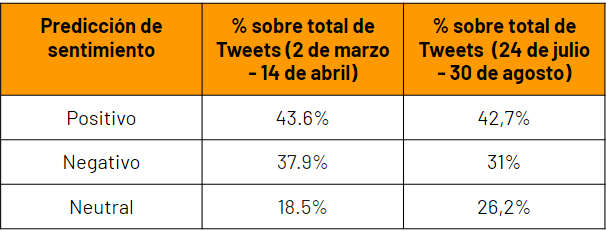

Esto último podría indicar, que comparando estas semanas de abril y agosto, en agosto habría disminuido levemente el sentimiento negativo asociado al coronavirus y que el aumento de un sentimiento neutral podría estar asociado a que el coronavirus se volvió más común por lo tanto genera un menor impacto.

## Planificacion futura.

Finalmente, para terminar y en base a los conocimientos adquiridos nos hubiese gustado investigar otros métodos para clasificar el lenguaje natural y comparar sus métricas con las métricas de los métodos enseñados en el curso, con el fin de que de alguna manera podamos mejorar nuestro clasificador. Ligado a los anterior nos hubiese interesado tambien haber tenido la posibilidad de probar el modelo con muchos otros dataset distintos, de diferentes volumenes, para generar un clasificador mas fiel.

## Referencias

[1] Coronavirus tweets NLP - Text Classification. (2020, 8 septiembre). Kaggle. https://www.kaggle.com/datatattle/covid-19-nlp-text-classification?select=Corona_NLP_test.csv

[2] Auxiliar 2 - Word Embeddings (2020, 17 Mayo). Github. https://github.com/dccuchile/CC6205/blob/master/tutorials/Auxiliar_2.ipynb

[3] COVID19 Tweets. (2020, 30 Agosto). Kaggle. https://www.kaggle.com/gpreda/covid19-tweets

## Contribuciones del equipo.

1. Nicolás Herrera: Análisis de resultados, conclusiones y creación presentación.
2. Yesenia Marulanda: Redacción de informe, creación de presentación y detalles.
3. Franco Migliorelli: Análisis de resultados y creación de presentación.
4. Samuel Sánchez: Explicación código, redacción y estructura de informe y presentación.
5. Sebastián Urbina: Limpieza de datos, aplicación Word2Vec, TF-IDF y entrenamiento modelos.